# Assignment 1: MATH 4753

## d.

```r
desert = filter(gob2, reg=="GS")
mean(desert$PlantCov)
```

```
## [1] 28
```

```r
median(desert$PlantCov)
```

```
## [1] 26
```

```r
getmode(desert$PlantCov)
```

```
## [1] 30
```

## e.

The center of the total plant coverage does appear to be different at the two regions. The coverage in the Gobi Desert is much lower than the coverage in the Dry Steppe.

## Question 14

### a.

```r
galaxy = read.csv("GALAXY2.csv", header = TRUE)
sp = with(ddt, galaxy$VELOCITY)

summary(galaxy)
```

```
##     VELOCITY
##  Min.   :18499
##  1st Qu.:19607
##  Median :22355
##  Mean   :21448
##  3rd Qu.:22803
##  Max.   :24909
```

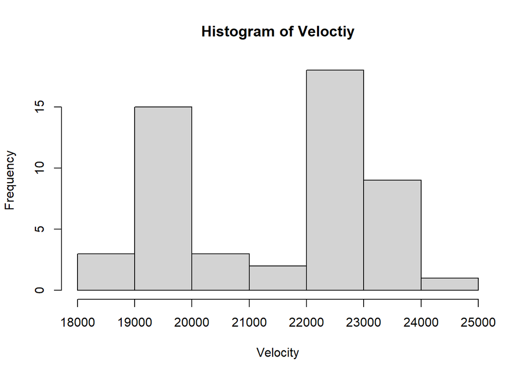

```r
hist(galaxy$VELOCITY, main="Histogram of Veloctiy", xlab="Velocity")
```

The values of velocity range from 18499 to 24909. The median is 22355 and the mean is 21448. The histogram shows that move rescorded velocities were between 19,000 and 20,000 and between 22,000 and 23,000.

### b.

The histogram does support a double cluster theory due to having two separate ranges with high frequencies, instead of being a uniform graph.

### c.

```r
print("First Cluster")
```

```
## [1] "First Cluster"
```

```r
A1775A <- filter(galaxy, VELOCITY < 21000)
mean(A1775A$VELOCITY)
```

```
## [1] 19462.24
```

```r
median(A1775A$VELOCITY)
```

```
## [1] 19408
```

```r
getmode(A1775A$VELOCITY)
```

```
## [1] 20210
```

```r
print("Second Cluster")
```

```
## [1] "Second Cluster"
```

```r
A1775B <- filter(galaxy, VELOCITY >= 21000)
mean(A1775B$VELOCITY)
```

```
## [1] 22838.47
```

```r
median(A1775B$VELOCITY)
```

```
## [1] 22780
```

```r
getmode(A1775B$VELOCITY)
```

```
## [1] 22922
```

### d.

If the velocity is 20,000 km/s then it is most likely to belong to cluster A1775A. This is because that cluster’s mean and median are both about 19,400 which is much closer than cluster B’s.

## Question 15

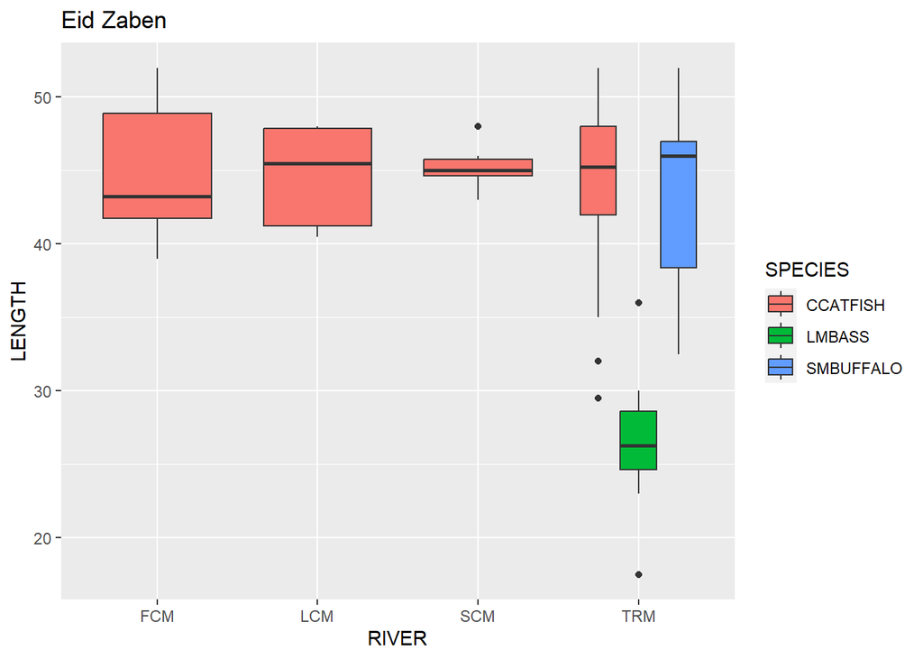

```r
library(ggplot2)

ddt = read.csv("DDT.csv")
library(ggplot2)

g <- ggplot(data = ddt, aes(x = RIVER, y = LENGTH, fill = SPECIES, given = RIVER))
g <- g + geom_boxplot()
g <- g + ggtitle("Eid Zaben")
g
```